# plotSortingMetaData

#### This Rmd script takes the FACS metadata and use ggplot to visulize them. The metadata can also be merged with sequencing data by cell names (containing plate and index information) to visulize gene expression or seurat cluster identity on the same plot with FACS measurements.

```r
library(Seurat)
library(dplyr)
library(Matrix)
```

##### First we will read the metadata exported from SONY, and the seurat object

```r
B003935<-read.csv(file="Trachea_B003935.csv",header=TRUE,sep=",",stringsAsFactors = F)
load("seurat_Trachea_May.RData")
```

###### This is what it looks like:

```r
head(B003935)
```

```
##          TIME    FSC.A     FSC.H FSC.W    BSC.A    BSC.H BSC.W
## 1 0.000000000 232434.8 163443.80   241 30473.37 14920.64   241
## 2 0.002194286 112600.5  69679.68   193 38810.36 27005.44   193
## 3 0.048148570 131515.5  84208.32   196 58964.55 34754.72   196
## 4 0.075314280 319795.2 161884.80   301 36663.49 16886.24   301
## 5 0.091234290 269946.0 147420.00   278 46152.59 16778.72   278
## 6 0.124034300 191147.4 156162.70   218 45778.99 28708.96   218
##   Hoechst.33342.A.Compensated EGFP.A.Compensated tdTomato.A.Compensated
## 1                   32.163350          1.8408690               39.31941
## 2                  135.226100         65.8953300             2642.43800
## 3                  107.146400         79.7796300             2866.71300
## 4                   -3.629883         25.5777100               15.33625
## 5                  -74.542240          0.4537354               25.35732
## 6                   19.899540         -9.6840090             1605.29000
##   Index
## 1
## 2
## 3
## 4
## 5
## 6
```

###### If you export the whole giant metadata table including all events (in and out of sorting gates), and you want to remove the events that did not get into wells (aka the events that don’t have any value in the “Index” column), you may do this:

```r
B003935_sort<-B003935[B003935$Index!="",]
head(B003935_sort)
```

```
##          TIME     FSC.A     FSC.H FSC.W    BSC.A    BSC.H BSC.W
## 144  7.301223 356882.30 229773.60   277 74486.38 40830.72   277
## 343 18.243490 114541.10  81651.36   186 44091.76 26847.52   186
## 387 21.054080 131980.30  73244.64   216 18361.35 14542.08   216
## 418 22.480140  69893.23  63430.08   132 48922.08 39670.40   132
## 529 27.687450 283585.20 188351.50   258 29030.77 18012.96   258
## 562 29.219060 298296.90 205383.40   257 36372.25 18486.72   257
##     Hoechst.33342.A.Compensated EGFP.A.Compensated tdTomato.A.Compensated
## 144                  1545.95400          3885.2580               763.1699
## 343                  3195.69700          3284.0970               956.9667
## 387                    72.13096          1135.3490               655.8939
## 418                  1328.38100           785.2992               889.2435
## 529                    46.66992          2245.7180               367.1626
## 562                    14.72695          2969.3870               343.7499
##     Index
## 144    A1
## 343    A2
## 387    A3
## 418    A4
## 529    A5
## 562    A6
```

###### add plate# into sorting metadata

```r
B003935_sort$plate<-rep("B003935",352)
#352 is the number of cells in the metadata.
```

##### we can use the plate# and index in the names of cells in sequencing data to link to their sorting metadata:

###### First let’s extract plate and index information from sequencing data

```r
cell_name<-read.table(text=names(seuTrachea_May@ident),sep="_",colClasses = "character")
colnames(cell_name)<-c("plate","well","tissue","other") # depends on what your cell names look like. My cell names are of this format.
head(cell_name)
```

```
##     plate well  tissue    other
## 1 B003935  A11 Trachea S513.mus
## 2 B003935  A12 Trachea S529.mus
## 3 B003935  A13 Trachea S545.mus
## 4 B003935  A14 Trachea S561.mus
## 5 B003935  A15 Trachea S577.mus
## 6 B003935  A16 Trachea S593.mus
```

###### We can also extract expression levels of genes.

```r
Tdtomato<-seuTrachea_May@data[which(rownames(seuTrachea_May@data)=="Tdtom_transgene"),]
Gfp<-seuTrachea_May@data[which(rownames(seuTrachea_May@data)=="Gfp_transgene"),]
```

###### Now we can make a dataframe that has the plate #, index#, seurat cluster identity, and expression levels of some genes

```r
cluster_cell<-cbind(cell_name[,1:2],seuTrachea_May@ident,Tdtomato,Gfp)
colnames(cluster_cell)<-c("plate","Index","identity","Tdtom_transgene","Gfp_transgene")
head(cluster_cell)
```

```
##                                plate Index identity Tdtom_transgene
## B003935_A11_Trachea_S513.mus B003935   A11        2       0.0000000
## B003935_A12_Trachea_S529.mus B003935   A12        3       0.7270986
## B003935_A13_Trachea_S545.mus B003935   A13        3       0.6808289
## B003935_A14_Trachea_S561.mus B003935   A14        0       0.3742038
## B003935_A15_Trachea_S577.mus B003935   A15        2       0.2910980
## B003935_A16_Trachea_S593.mus B003935   A16        1       0.4466490
##                              Gfp_transgene
## B003935_A11_Trachea_S513.mus    2.32330849
## B003935_A12_Trachea_S529.mus    0.01344177
## B003935_A13_Trachea_S545.mus    0.11855860
## B003935_A14_Trachea_S561.mus    0.24082629
## B003935_A15_Trachea_S577.mus    0.00000000
## B003935_A16_Trachea_S593.mus    0.00000000
```

##### now we can join the above dataframe with FACS metadata.

```r
join_B003935<-left_join(B003935_sort,cluster_cell)
```

##### now we can plot metadata for all cells and color code them based on cluster identities:

###### if you only want to see one column of metadata (Hoechst signal for example):

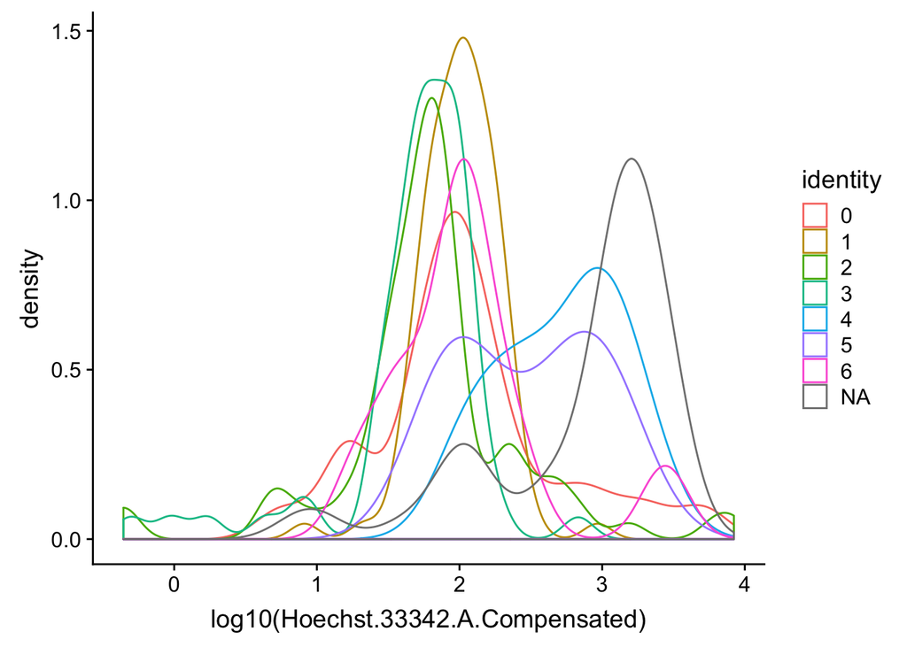

```r
ggplot(join_B003935,aes(x=log10(Hoechst.33342.A.Compensated)))+geom_density(aes(color=identity))
```

###### if you want to see Hoechst on x axis, and GFP on y axis:

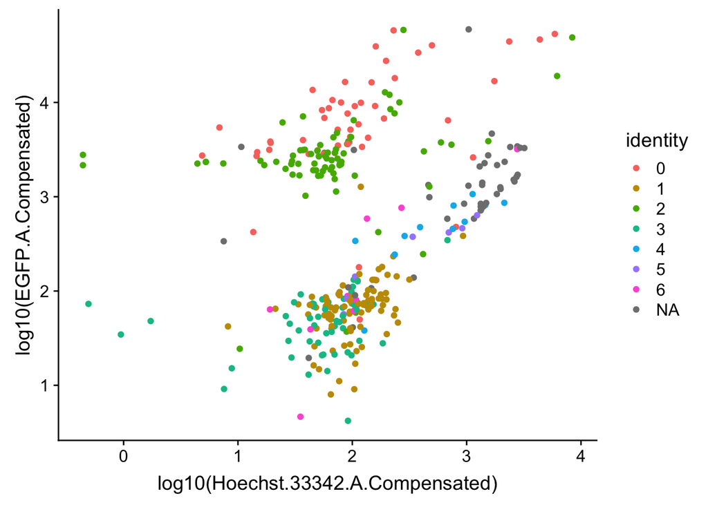

```r
ggplot(join_B003935,aes(x=log10(Hoechst.33342.A.Compensated),y=log10(EGFP.A.Compensated)))+geom_point(aes(color=identity))
```

###### If you want to color code cells by mRNA levels instead of cluster identities:

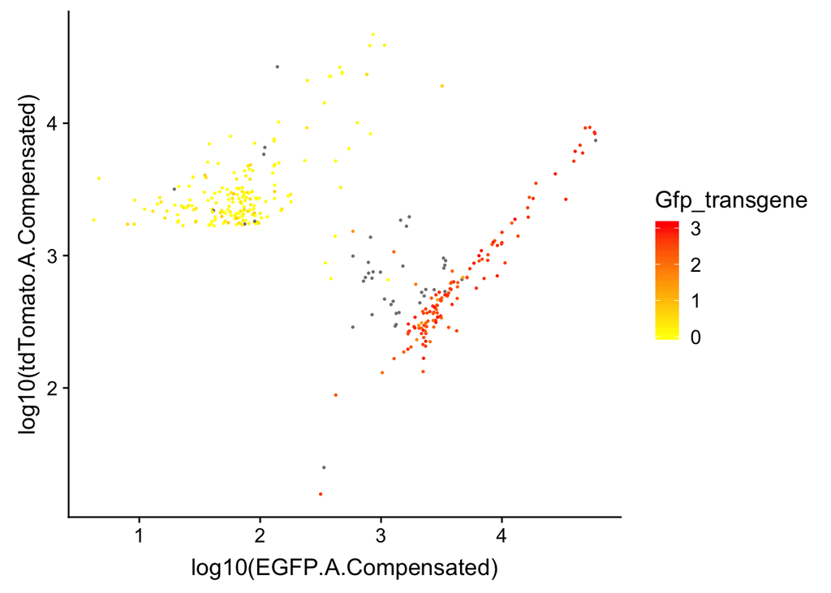

```r
ggplot(join_B003935,aes(x=log10(EGFP.A.Compensated),y=log10(tdTomato.A.Compensated),color=Gfp_transgene))+geom_point(size=0.3)+scale_color_continuous(low="yellow",high="red")
```